# Bayesian Models in Species Interactions

Ben Weinstein

December 2, 2016

# Aim

A short tutorial explaining the different options for fitting hierarchical bayesian models for species interactions using the package alienR

```r
library(alienR)
library(ggplot2)
library(knitr)
opts_chunk$set(warning=F,message=F)

#source scripts because I can't seem to understand how roxygen generates functions to the package! To delete once we understand how paths are handled in package creation
s<-sapply(list.files("C:/Users/Ben/Documents/alienR/R",pattern=".R",full.names = T),source)
```

# Simulate data

For this example, let’s similiar some interaction data on trait-matching among species

```r
dat<-sim.traitmatch(size_x = 10,size_y = 20,traits_x = rpois(10,7),traits_y = rpois(20,10),alpha_sigma = 3,replicates=3)
```

We can view the trait-matching in this simulated dataset

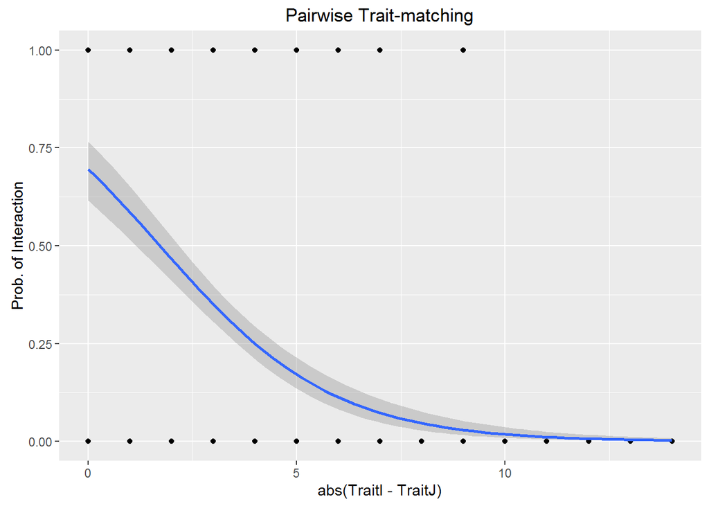

```r
ggplot(dat,aes(x=abs(TraitI-TraitJ),y=Interactions)) + geom_point() + geom_smooth(method="glm",method.args=list(family="binomial")) + ggtitle("Pairwise Trait-matching") + labs(y="Prob. of Interaction")
```

# Intercept Model

We can then fit a hierarchical bayesian model. The simplest model is an intercept model, such that the probability of interaction is fixed for each pair of species.

```r
intercept<-fit.bayesreg(dat = dat,algorithm = "Intercept")
```

Get the matrix of probability of interactions among observed species. Since this is the intercept model, we are just interested in the probabilities of our observed matrix. This is the default of the predict function.

```r
predframe<-predict.bayesreg(intercept)

#summarize mean, lower 5th and upper 9th
sumframe<-predframe %>% group_by(I,J) %>% summarize(mean=mean(value),lower=quantile(value,0.05),upper=quantile(value,0.95))
```

## View interactions

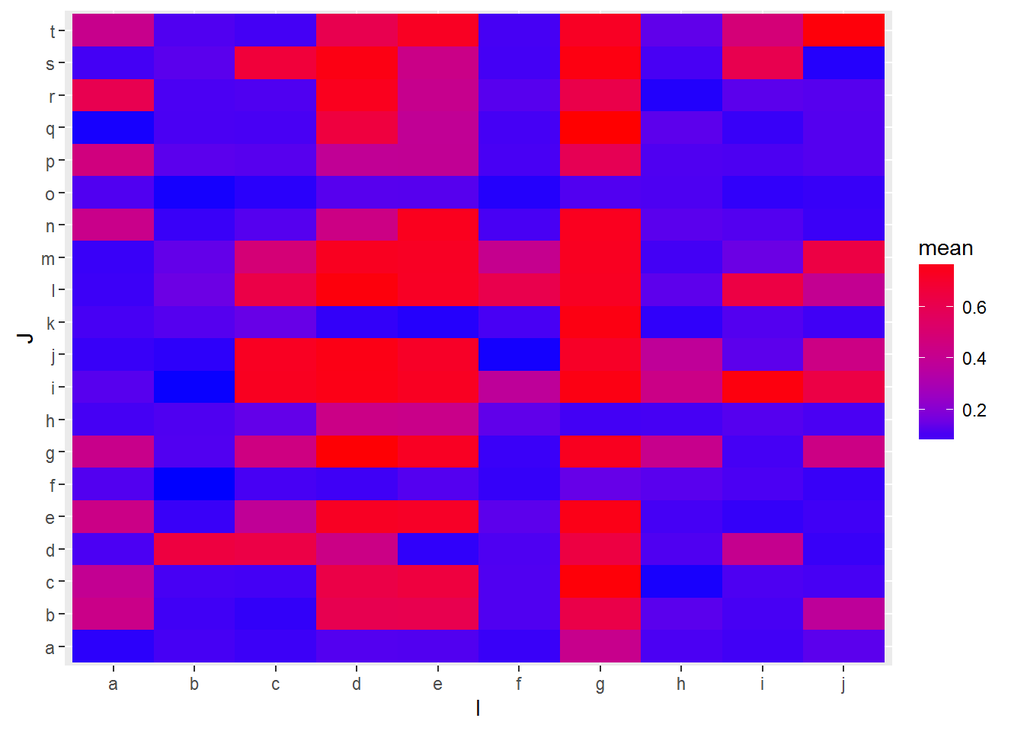

```r
ggplot(sumframe,aes(x=as.factor(I),y=J,fill=mean)) + geom_tile() + scale_fill_continuous(low="blue",high="red") + labs(x="I")
```

But wait, there’s more! Since we fit the model using MCMC, we have built in estimates in the uncertainty in species interactions.

Upper 95th estimate

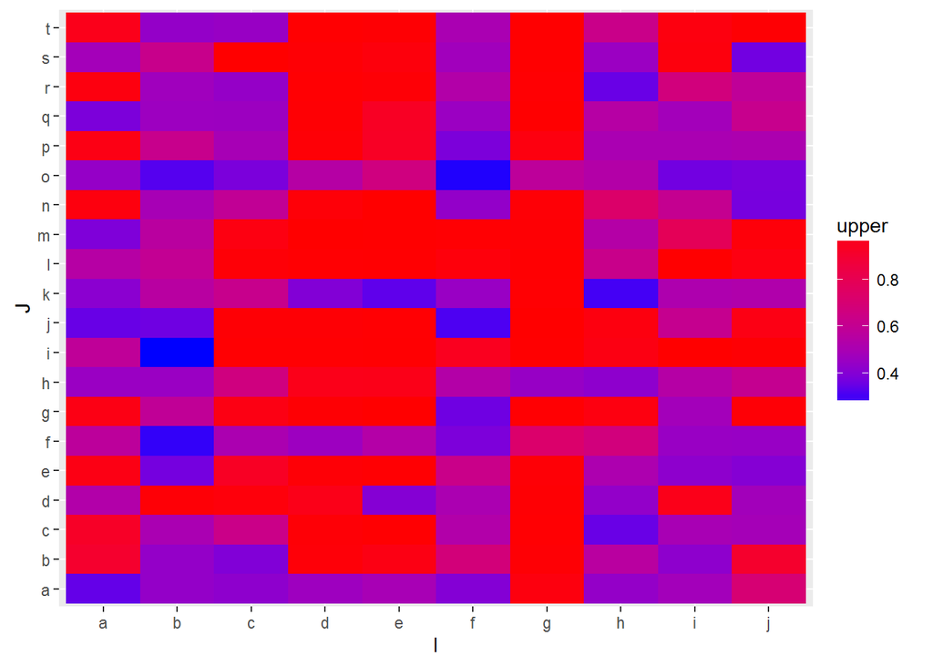

```r
ggplot(sumframe,aes(x=as.factor(I),y=J,fill=upper)) + geom_tile() + scale_fill_continuous(low="blue",high="red") + labs(x="I")
```

Lower 5th estimate

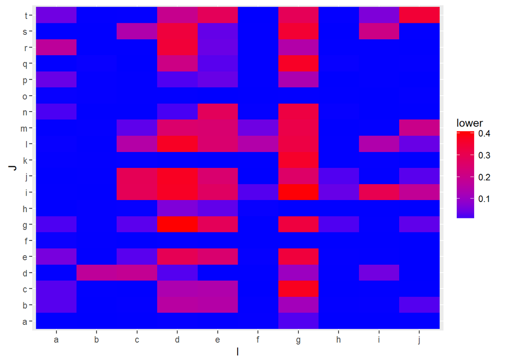

```r
ggplot(sumframe,aes(x=as.factor(I),y=J,fill=lower)) + geom_tile() + scale_fill_continuous(low="blue",high="red") + labs(x="I")
```

If we want the distributions, instead of a summary we can plot the posterior predictions directly. For the sake of plotting, lets look at just one node.

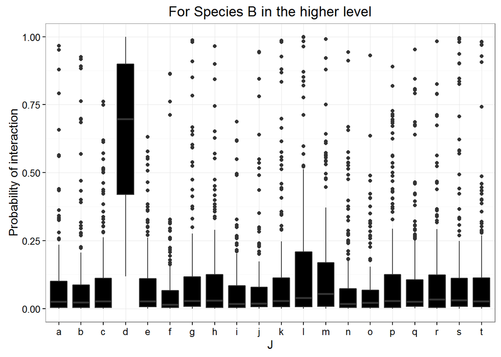

```r
justB<-predframe %>% filter(I=="b")
ggplot(data=justB,aes(x=J,y=value)) + geom_boxplot(fill="black") + labs(y="Probability of interaction") + ggtitle("For Species B in the higher level") + theme_bw()
```

# Binomial Model

An intercept model may work well in some situations, but we often are collecting data to test some underlying ecological mechansim. For example, to test trait-matching among network partners. IN the intercept model, we never used the trait values we simulated. Let’s correct that.

```r
binomial<-fit.bayesreg(dat=dat,algorithm = "Binomial")
```

Just as before, we can get the predicted matrix based on the model fit.

```r
predframe2<-predict.bayesreg(binomial)

#summarize mean, lower 5th and upper 9th
sumframe<-predframe2 %>% group_by(I,J) %>% summarize(mean=mean(value),lower=quantile(value,0.05),upper=quantile(value,0.95),Traitmatch=unique(Traitmatch))
```

## View interactions

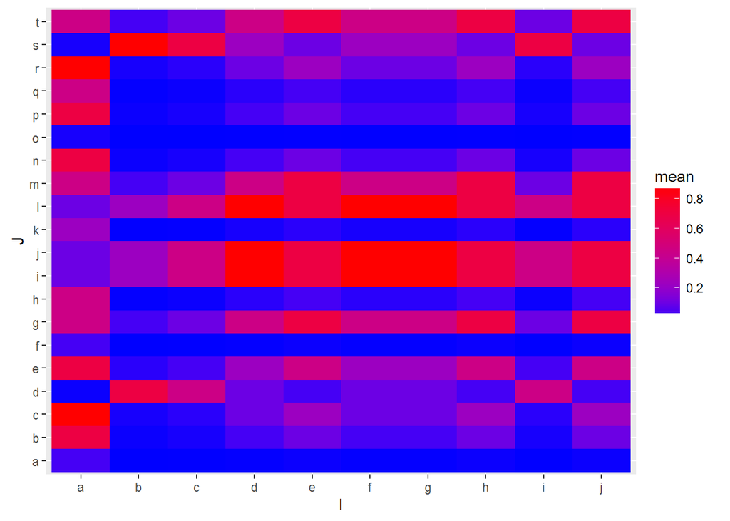

```r
ggplot(sumframe,aes(x=as.factor(I),y=J,fill=mean)) + geom_tile() + scale_fill_continuous(low="blue",high="red") + labs(x="I")
```

Upper 95th estimate

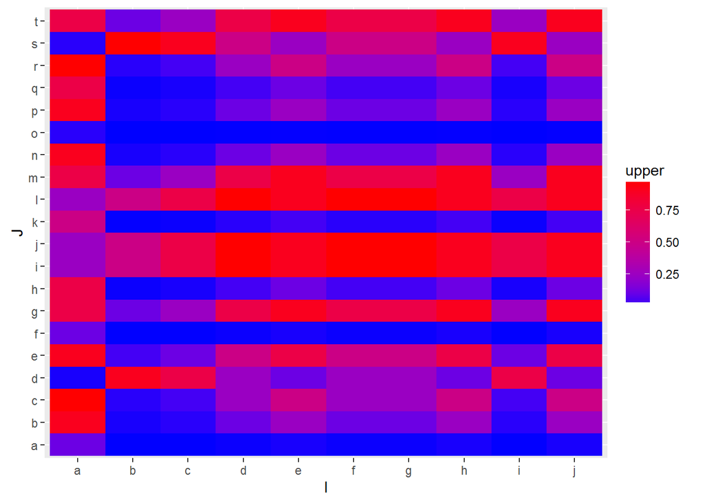

```r
ggplot(sumframe,aes(x=as.factor(I),y=J,fill=upper)) + geom_tile() + scale_fill_continuous(low="blue",high="red") + labs(x="I")
```

Lower 5th estimate

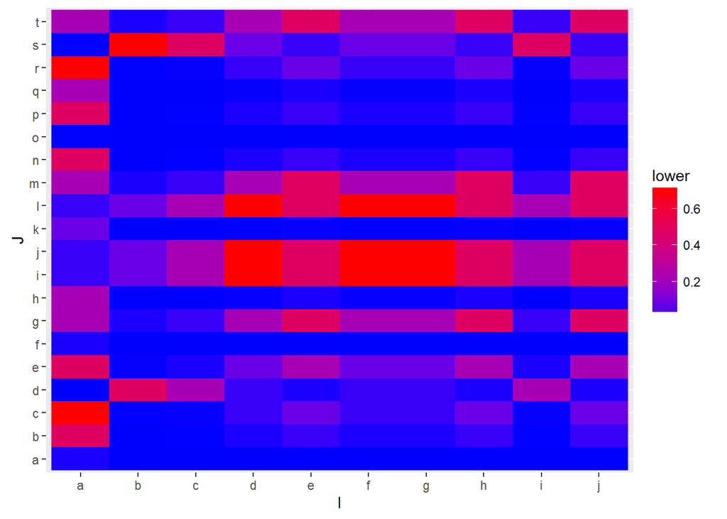

```r
ggplot(sumframe,aes(x=as.factor(I),y=J,fill=lower)) + geom_tile() + scale_fill_continuous(low="blue",high="red") + labs(x="I")
```

Create the same boxplot as in the intercept model

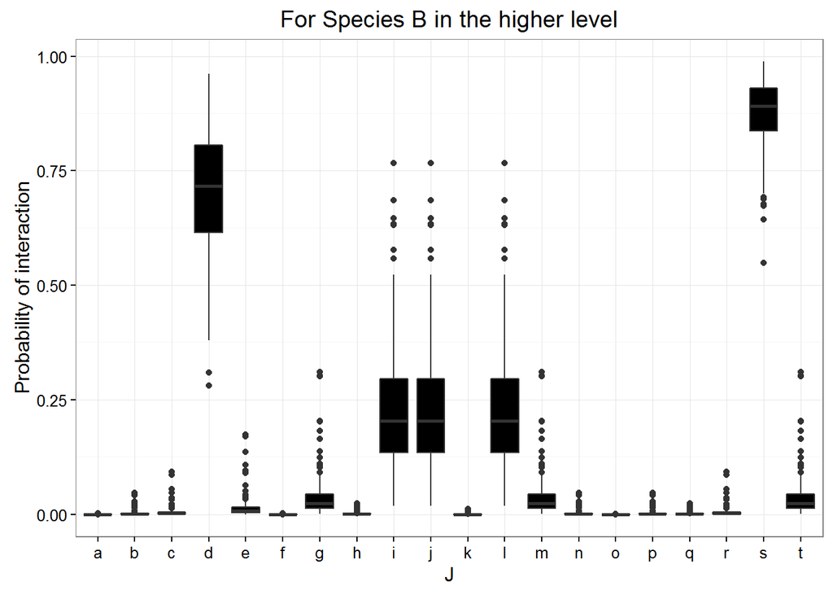

```r
justB<-predframe2 %>% filter(I=="b")
ggplot(data=justB,aes(x=J,y=value)) + geom_boxplot(fill="black") + labs(y="Probability of interaction") + ggtitle("For Species B in the higher level") + theme_bw()
```

Notice that as we added information the confidence intervals greatly decreased.

## View trait-matching function

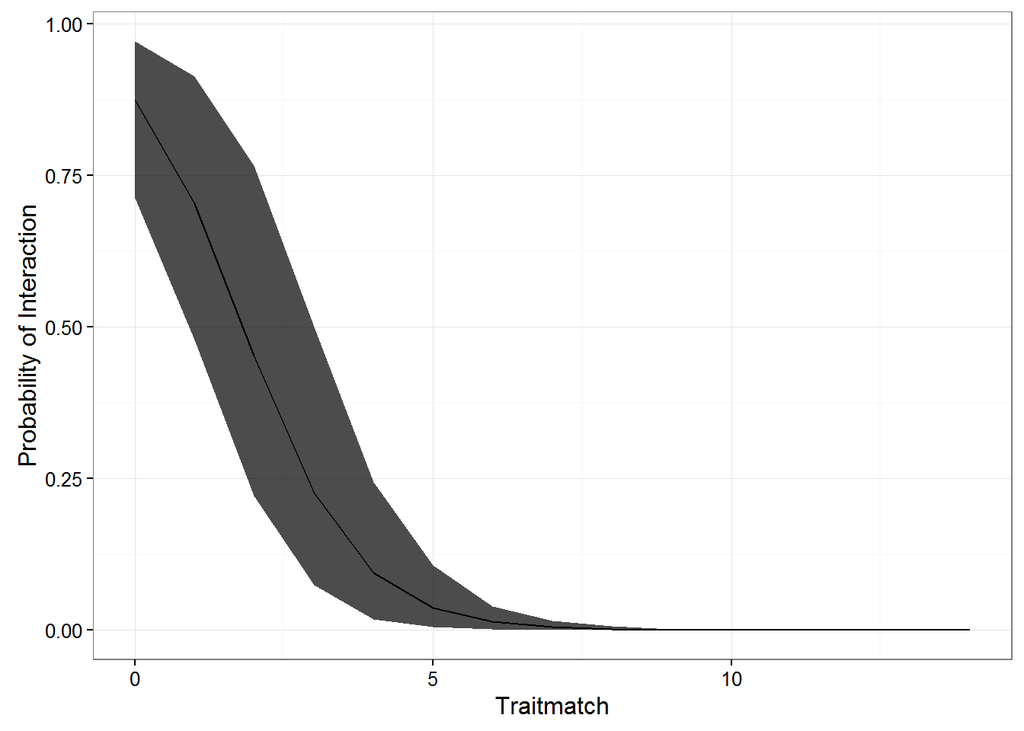

```r
ggplot(sumframe,aes(x=Traitmatch,y=mean,ymin=lower,ymax=upper)) + geom_line() + geom_ribbon(alpha=0.7,fill="black") + labs(y="Probability of Interaction") + theme_bw()
```

# Generate networks and statistics

One of the virtues of having a posterior distribution of interaction probabilities is that we can attach uncertainty to our predicted networks. By taking a binomial draw for each of our predicted interactions, we generate a binary network. From that binary network we can calculate our desired network statistics.

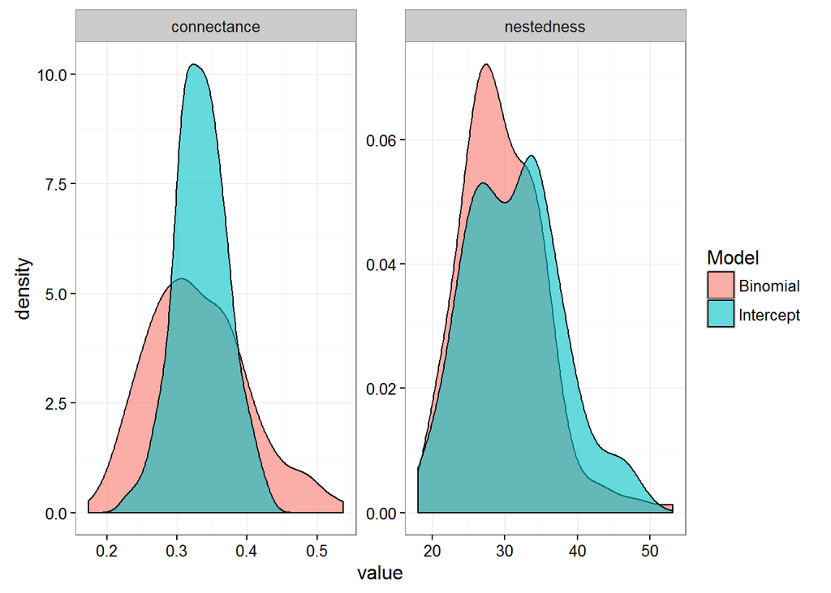

```r
intercept_stats<-network.bayesreg(predframe,indices=c("nestedness","connectance"))
intercept_stats$Model<-"Intercept"
binomial_stats<-network.bayesreg(predframe2,indices=c("nestedness","connectance"))
binomial_stats$Model<-"Binomial"

allstats<-rbind_all(list(intercept_stats,binomial_stats))

#plot distribution fo variables
ggplot(allstats,aes(x=nstat)) + geom_density(alpha=0.6,aes(fill=Model)) + facet_wrap(~Metric,scales='free',nrow=1) + theme_bw()  + labs(x="value")
```

Same data, different model, different network statistics! Models matter.